# EGRMGMT 590.21 Homework 8 (Questions)

## Instructions

- Use R Markdown to complete the exercises in order. Please show both your R code and its corresponding output
- There are 10 exercises in total, each of which is worth 10 points
- One exercise can be potentially solved in multiple ways. The grade is based on the output accuracy, not on performance
- Submit the completed homework in a .html file to Sakai by **6:15pm ET on Thursday, November 7**. Assignments handed in late will lose 10 points each day after the due date
- For more information about R Markdown, please visit the two links in the References/Readings slide in the week 2 deck

## Exercises

### Data Introduction

Read the “music.csv” file into a dataframe named df. The dataset includes customer information for a fictitious music subscription service. The variables included are:

- age (in years)
- sex
- household income (in US dollars)
- annual miles driven in a car
- number of children under 18 years old living at home
- whether regularly commutes by car
- reported enthusiasm for driving based on survey responses (rating is on a 1-to-7 scale with 7 being the highest)
- reported enthusiasm for music based on survey responses (rating is on a 1-to-7 scale with 7 being the highest)
- whether subscribes to the music service
- a known assignment to one of the six customer segments based on prior research

### Exercise 1 (10 Points)

- Use the hclust() function in the cluster library to conduct hierarchical clustering for the data in df (excluding the “Segment” column)
- Plot the complete cluster dendrogram
- Based on the hierarchical clustering output, cut the data into 4 clusters and show the number of observations by cluster

```r
music.q1<- read.csv("music.csv")
music1.df <- music.q1[,c(1:9)]



dist1 <- dist(as.matrix(music1.df))
```

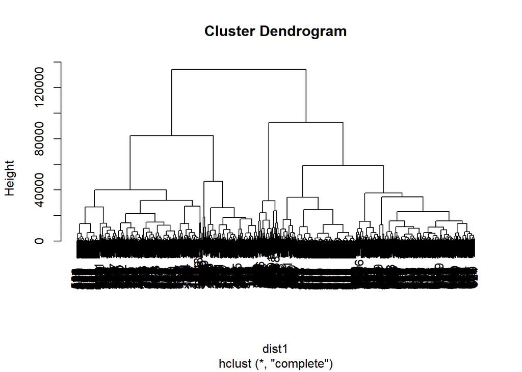

```r
musicq1 <- hclust(dist1, method = "complete")
musicq1a <- hclust(dist1, method = "single")
plot(musicq1)
```

```r
subgroup <- cutree(musicq1, k = 4)
table(subgroup)
```

```
## subgroup
##   1   2   3   4
## 283 125 437  50
```

### Exercise 2 (10 Points)

- Make a copy of df and name the new dataframe df.num
- In df.num, recode the binary factors “sex”, “commuteCar”, and “subscribeToMusic” to numeric using the ifelse() function. For example, “subscribeToMusic” can be recoded to a numeric variable with numeric values 0s and 1s, where 0 indicates “subNo” and 1 indicates “subYes”
- Use the kmeans() function to conduct kmeans clustering (with k = 4) for the data in df.num (excluding “Segment”)
- What are the centers of the four clusters?

```r
df.num <- na.omit(music.q1[,c(1:9)])
df.num$sex <- ifelse(music.q1$sex == "Male", 1, 0)
df.num$commuteCar <- ifelse(music.q1$commuteCar == "carNo", 0, 1)
df.num$subscribeToMusic <- ifelse(music.q1$subscribeToMusic == "subNo", 0, 1)

object.kmean <- kmeans(as.matrix(df.num),centers = 4 )
object.kmean$size
```

```
## [1]  50 297 333 215
```

### Exercise 3 (10 Points)

- Use the elbow method to determine the appropriate number of clusters for kmeans clustering of df.num (excluding “Segment”)
- Create a line chart with the number of clusters (ranging from 1 to 20) as the horizontal axis and the average within-cluster sum of squared deviations from the cluster center as the vertical axis
- Based on the elbow method, what is the appropriate number of clusters for kmeans clustering of df.num?

```r
library(rlang)
library(purrr)
```

```r
wssmusic <- function(k) {
  kmeans(df.num, k, nstart = 10 )$tot.withinss
}

total.values <- 1:20


q2_values <- map_dbl(total.values, wssmusic)

?map_dbl()
```

```
## starting httpd help server ...
```

```
##  done
```

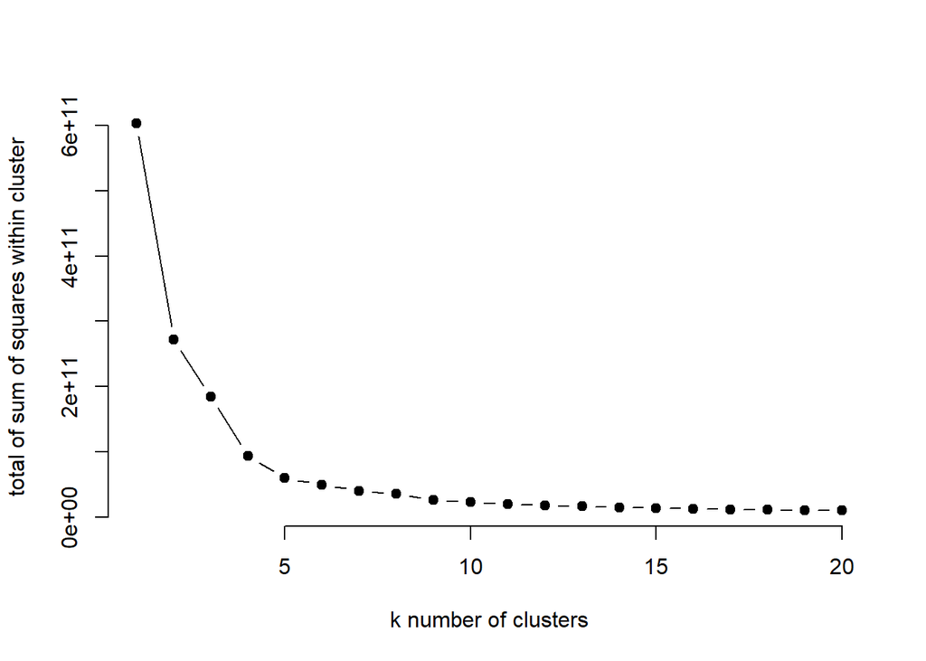

```r
plot(total.values, q2_values,
       type="b", pch = 19, frame = FALSE,
       xlab="k number of clusters",
       ylab="total of sum of squares within cluster")
```

```r
#Appropriate number of k mean clusters  = 4
```

### Exercise 4 (10 Points)

- For the k-means clustering of df.num (excluding “Segment”), create another line chart with the number of clusters (ranging from 1 to 20) as the horizontal axis and the percentage of variance explained (i.e. the ratio of the between-group variance to the total variance) as the vertical axis
- Based on the elbow method, what is the appropriate number of clusters for kmeans clustering of df.num?

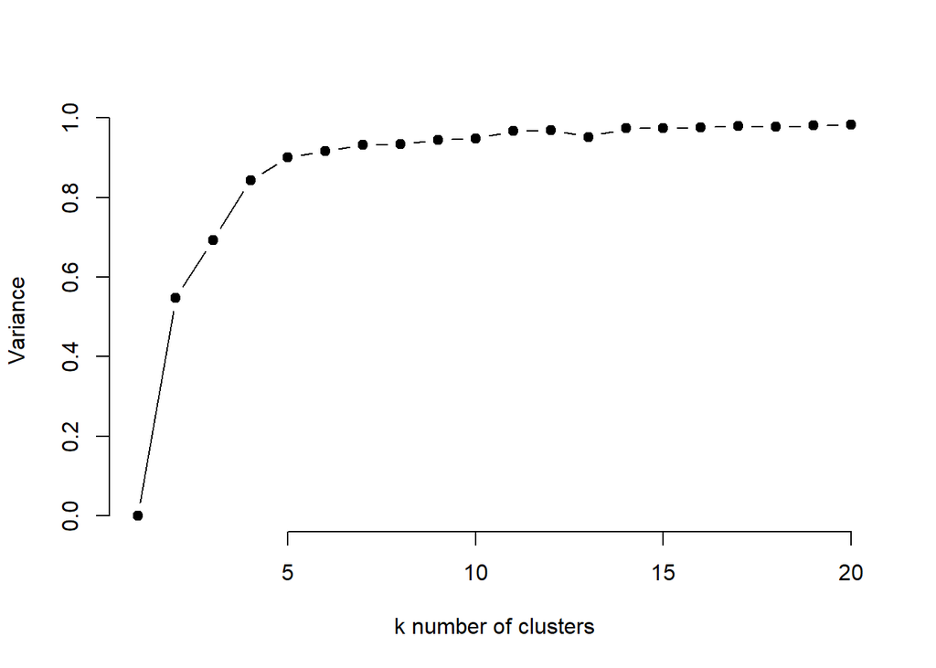

```r
library(purrr)

wssmusic <- function(k) {
  kmeans(df.num, k)$betweens/kmeans(df.num, k)$totss
}

total.values <- 1:20


q2_values <- map_dbl(total.values, wssmusic)

plot(total.values, q2_values,
       type="b", pch = 19, frame = FALSE,
       xlab="k number of clusters",
       ylab="Variance")
```